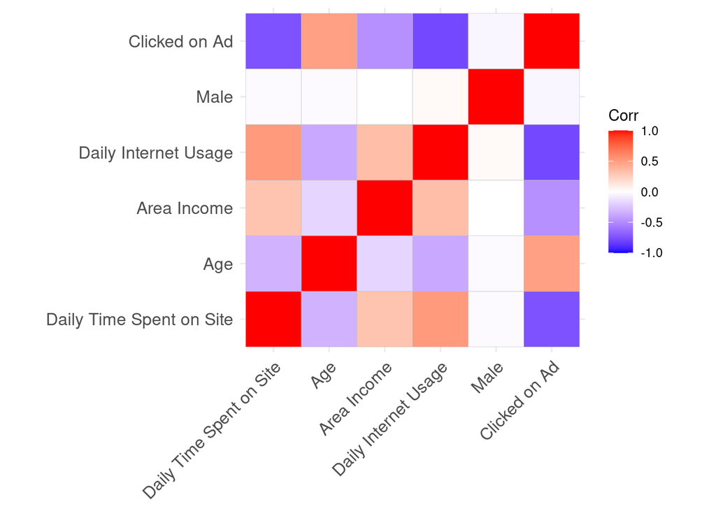

```r
install.packages("ggcorrplot")
library(ggplot2)
library(ggcorrplot)
ggcorrplot(r)
```

Supervised Learning with R Using R We begin by installing the caret package

```r
install.packages('caret')
library(caret)
loaded_packages  <- library()$results[,1]
# confirm caret is loaded
"caret" %in% tolower(loaded_packages)
```

```
## [1] TRUE
```

Load the caret library

```r
library(caret)
```

Let’s preview the dataset we will be modelling

```r
head(df2)
```

```
##    Daily Time Spent on Site Age Area Income Daily Internet Usage Male
## 1:                    68.95  35    61833.90               256.09    0
## 2:                    80.23  31    68441.85               193.77    1
## 3:                    69.47  26    59785.94               236.50    0
## 4:                    74.15  29    54806.18               245.89    1
## 5:                    68.37  35    73889.99               225.58    0
## 6:                    59.99  23    59761.56               226.74    1
##    Clicked on Ad
## 1:             0
## 2:             0
## 3:             0
## 4:             0
## 5:             0
## 6:             0
```

Let’s change the column name

```r
# get column names
colnames(df2)
```

```
## [1] "Daily Time Spent on Site" "Age"
## [3] "Area Income"              "Daily Internet Usage"
## [5] "Male"                     "Clicked on Ad"
```

```r
names(df2)[names(df2) == "Clicked on Ad"] <- "clicked"
names(df2)[names(df2) == "Area Income"] <- "area_income"
names(df2)[names(df2) == "Daily Time Spent on Site"] <- "daily_time_spent_on_site"
names(df2)[names(df2) == "Daily Internet Usage"] <- "daily_internet_usage"
df2
```

```
##       daily_time_spent_on_site Age area_income daily_internet_usage Male
##    1:                    68.95  35    61833.90               256.09    0
##    2:                    80.23  31    68441.85               193.77    1
##    3:                    69.47  26    59785.94               236.50    0
##    4:                    74.15  29    54806.18               245.89    1
##    5:                    68.37  35    73889.99               225.58    0
##   ---
##  996:                    72.97  30    71384.57               208.58    1
##  997:                    51.30  45    67782.17               134.42    1
##  998:                    51.63  51    42415.72               120.37    1
##  999:                    55.55  19    41920.79               187.95    0
## 1000:                    45.01  26    29875.80               178.35    0
##       clicked
##    1:       0
##    2:       0
##    3:       0
##    4:       0
##    5:       0
##   ---
##  996:       1
##  997:       1
##  998:       1
##  999:       0
## 1000:       1
```

Let’s split our data into test and train

```r
intrain <- createDataPartition(y = df2$clicked, p =0.7, list = FALSE)
train <- df2[intrain,]
test <- df2[-intrain,]
```

Let’s check the dimensions of our training df and testing df

```r
dim(train);
```

```
## [1] 700   6
```

```r
dim(test);
```

```
## [1] 300   6
```

Since the outcome variable is either 0 or 1, we need to change it into a categorical variable

```r
train[["clicked"]] = factor(train[["clicked"]])
```

Before training the model, we need to control all the computational overheads

```r
trctrl <- trainControl(method = "repeatedcv", number = 10, repeats = 3)
```

```r
svm_Linear <- train(
   clicked~., data = train, method ="svmLinear",
   trControl = trctrl,
   preProcess = c("center", "scale"),
   tuneLength = 5)
```

```r
svm_Linear
```

```
## Support Vector Machines with Linear Kernel
##
## 700 samples
##   5 predictor
##   2 classes: '0', '1'
##
## Pre-processing: centered (5), scaled (5)
## Resampling: Cross-Validated (10 fold, repeated 3 times)
## Summary of sample sizes: 630, 630, 630, 630, 630, 630, ...
## Resampling results:
##
##   Accuracy  Kappa
##   0.97      0.94
##
## Tuning parameter 'C' was held constant at a value of 1
```

Let’s Predict the results

```r
test_pred <- predict(svm_Linear , newdata = test)
test_pred
```

```
##   [1] 0 1 1 0 0 0 0 1 0 0 1 0 0 1 1 1 1 1 0 1 1 0 1 1 0 1 1 0 1 0 0 0 0 0 0 0 1
##  [38] 0 0 0 0 1 0 0 0 0 1 1 0 0 1 1 0 0 1 0 1 0 1 0 0 0 0 1 1 1 1 1 0 1 1 1 1 1
##  [75] 0 1 1 0 1 1 1 0 1 0 0 1 0 1 1 0 0 0 0 0 0 1 0 0 1 1 0 0 0 0 1 1 1 0 0 1 1
## [112] 1 0 1 0 0 1 1 0 1 1 0 0 1 0 0 0 0 1 0 1 1 1 0 1 1 1 1 1 1 0 1 1 1 0 0 0 0
## [149] 1 0 1 0 1 0 1 0 1 0 0 1 1 1 1 0 0 0 1 0 0 0 0 1 0 0 1 0 0 0 1 1 0 1 0 1 0
## [186] 0 1 1 0 0 0 0 0 0 1 1 1 1 0 0 1 1 1 0 1 1 0 1 0 0 0 0 1 1 0 0 1 1 1 0 1 1
## [223] 1 0 1 0 0 0 1 0 0 1 1 1 0 1 1 1 0 0 0 0 1 0 1 1 1 1 1 0 0 1 0 1 0 0 1 1 0
## [260] 0 1 0 0 0 1 0 1 0 1 1 1 0 0 1 1 1 1 0 1 1 1 1 0 0 1 1 0 0 1 1 0 0 1 0 1 1
## [297] 1 1 0 1
## Levels: 0 1
```

Let us now check for the accuracy of our model

```r
confusionMatrix(table(test_pred, test$clicked))
```

```
## Confusion Matrix and Statistics
##
##
## test_pred   0   1
##         0 144   6
##         1   6 144
##
##                Accuracy : 0.96
##                  95% CI : (0.9312, 0.9792)
##     No Information Rate : 0.5
##     P-Value [Acc > NIR] : <2e-16
##
##                   Kappa : 0.92
##
##  Mcnemar's Test P-Value : 1
##
##             Sensitivity : 0.96
##             Specificity : 0.96
##          Pos Pred Value : 0.96
##          Neg Pred Value : 0.96
##              Prevalence : 0.50
##          Detection Rate : 0.48
##    Detection Prevalence : 0.50
##       Balanced Accuracy : 0.96
##
##        'Positive' Class : 0
##
```

```r
confusionMatrix
```

```
## function (data, ...)
## {
##     UseMethod("confusionMatrix")
## }
## <bytecode: 0x55bf786aa190>
## <environment: namespace:caret>
```

The model is 96% accurate